# assingment_week_2_brain_tSNE_grid_search

```python
# libraries
import numpy as np
import pandas as pd
import matplotlib.pyplot as plt
from sklearn.preprocessing import StandardScaler
from sklearn.decomposition import PCA
from sklearn.manifold import TSNE
from sklearn.pipeline import Pipeline
from sklearn.cluster import KMeans
from sklearn.model_selection import GridSearchCV
```

```python
def plot_data(X, df):
    #add x, y features to the original df
    df['x'] = X[:,0]
    df['y'] = X[:,1]
    sns.scatterplot(x = 'x', y = 'y', hue = 'type', data = df, alpha = 0.5)#, palette=['red','blue'])
    #the len of colors should be as the number of 'type'!
    plt.legend(bbox_to_anchor=(1.05, 1), loc='upper left', borderaxespad=0)
    plt.show()
```

### Loading and preprocessing the data:

```python
df = pd.read_csv('../data/Brain_GSE50161.csv')
```

```python
df.shape
```

```
(130, 54677)
```

```python
df.head()
```

|  | samples | type | 1007_s_at | 1053_at | 117_at | 121_at | 1255_g_at | 1294_at | 1316_at | 1320_at | ... | AFFX-r2-Ec-bioD-3_at | AFFX-r2-Ec-bioD-5_at | AFFX-r2-P1-cre-3_at | AFFX-r2-P1-cre-5_at | AFFX-ThrX-3_at | AFFX-ThrX-5_at | AFFX-ThrX-M_at | AFFX-TrpnX-3_at | AFFX-TrpnX-5_at | AFFX-TrpnX-M_at |
| --- | --- | --- | --- | --- | --- | --- | --- | --- | --- | --- | --- | --- | --- | --- | --- | --- | --- | --- | --- | --- | --- |
| 0 | 834 | ependymoma | 12.498150 | 7.604868 | 6.880934 | 9.027128 | 4.176175 | 7.224920 | 6.085942 | 6.835999 | ... | 9.979005 | 9.926470 | 12.719785 | 12.777792 | 5.403657 | 4.870548 | 4.047380 | 3.721936 | 4.516434 | 4.749940 |
| 1 | 835 | ependymoma | 13.067436 | 7.998090 | 7.209076 | 9.723322 | 4.826126 | 7.539381 | 6.250962 | 8.012549 | ... | 11.924749 | 11.215930 | 13.605662 | 13.401342 | 5.224555 | 4.895315 | 3.786437 | 3.564481 | 4.430891 | 4.491416 |
| 2 | 836 | ependymoma | 13.068179 | 8.573674 | 8.647684 | 9.613002 | 4.396581 | 7.813101 | 6.007746 | 7.178156 | ... | 12.154405 | 11.532460 | 13.764593 | 13.477800 | 5.303565 | 5.052184 | 4.005343 | 3.595382 | 4.563494 | 4.668827 |
| 3 | 837 | ependymoma | 12.456040 | 9.098977 | 6.628784 | 8.517677 | 4.154847 | 8.361843 | 6.596064 | 6.347285 | ... | 11.969072 | 11.288801 | 13.600828 | 13.379029 | 4.953429 | 4.708371 | 3.892318 | 3.759429 | 4.748381 | 4.521275 |
| 4 | 838 | ependymoma | 12.699958 | 8.800721 | 11.556188 | 9.166309 | 4.165891 | 7.923826 | 6.212754 | 6.866387 | ... | 11.411701 | 11.169317 | 13.751442 | 13.803646 | 4.892677 | 4.773806 | 3.796856 | 3.577544 | 4.504385 | 4.541450 |

5 rows × 54677 columns

```python
set(df.type)
```

```
{'ependymoma',
 'glioblastoma',
 'medulloblastoma',
 'normal',
 'pilocytic_astrocytoma'}
```

```python
df['type'].value_counts()
```

```
ependymoma               46
glioblastoma             34
medulloblastoma          22
pilocytic_astrocytoma    15
normal                   13
Name: type, dtype: int64
```

```python
df = df.set_index('samples')
```

```python
data = df.select_dtypes(include=np.number) # to keep the number data
```

```python
data.head()
```

| samples | 1007_s_at | 1053_at | 117_at | 121_at | 1255_g_at | 1294_at | 1316_at | 1320_at | 1405_i_at | 1431_at | ... | AFFX-r2-Ec-bioD-3_at | AFFX-r2-Ec-bioD-5_at | AFFX-r2-P1-cre-3_at | AFFX-r2-P1-cre-5_at | AFFX-ThrX-3_at | AFFX-ThrX-5_at | AFFX-ThrX-M_at | AFFX-TrpnX-3_at | AFFX-TrpnX-5_at | AFFX-TrpnX-M_at |
| --- | --- | --- | --- | --- | --- | --- | --- | --- | --- | --- | --- | --- | --- | --- | --- | --- | --- | --- | --- | --- | --- |
| 834 | 12.498150 | 7.604868 | 6.880934 | 9.027128 | 4.176175 | 7.224920 | 6.085942 | 6.835999 | 5.898355 | 5.513410 | ... | 9.979005 | 9.926470 | 12.719785 | 12.777792 | 5.403657 | 4.870548 | 4.047380 | 3.721936 | 4.516434 | 4.749940 |
| 835 | 13.067436 | 7.998090 | 7.209076 | 9.723322 | 4.826126 | 7.539381 | 6.250962 | 8.012549 | 5.453147 | 6.173106 | ... | 11.924749 | 11.215930 | 13.605662 | 13.401342 | 5.224555 | 4.895315 | 3.786437 | 3.564481 | 4.430891 | 4.491416 |
| 836 | 13.068179 | 8.573674 | 8.647684 | 9.613002 | 4.396581 | 7.813101 | 6.007746 | 7.178156 | 8.400266 | 6.323471 | ... | 12.154405 | 11.532460 | 13.764593 | 13.477800 | 5.303565 | 5.052184 | 4.005343 | 3.595382 | 4.563494 | 4.668827 |
| 837 | 12.456040 | 9.098977 | 6.628784 | 8.517677 | 4.154847 | 8.361843 | 6.596064 | 6.347285 | 4.900380 | 6.008684 | ... | 11.969072 | 11.288801 | 13.600828 | 13.379029 | 4.953429 | 4.708371 | 3.892318 | 3.759429 | 4.748381 | 4.521275 |
| 838 | 12.699958 | 8.800721 | 11.556188 | 9.166309 | 4.165891 | 7.923826 | 6.212754 | 6.866387 | 5.405628 | 5.279579 | ... | 11.411701 | 11.169317 | 13.751442 | 13.803646 | 4.892677 | 4.773806 | 3.796856 | 3.577544 | 4.504385 | 4.541450 |

5 rows × 54675 columns

```python
data.info()
```

```
<class 'pandas.core.frame.DataFrame'>
Int64Index: 130 entries, 834 to 963
Columns: 54675 entries, 1007_s_at to AFFX-TrpnX-M_at
dtypes: float64(54675)
memory usage: 54.2 MB
```

```python
data.describe()
```

|  | 1007_s_at | 1053_at | 117_at | 121_at | 1255_g_at | 1294_at | 1316_at | 1320_at | 1405_i_at | 1431_at | ... | AFFX-r2-Ec-bioD-3_at | AFFX-r2-Ec-bioD-5_at | AFFX-r2-P1-cre-3_at | AFFX-r2-P1-cre-5_at | AFFX-ThrX-3_at | AFFX-ThrX-5_at | AFFX-ThrX-M_at | AFFX-TrpnX-3_at | AFFX-TrpnX-5_at | AFFX-TrpnX-M_at |
| --- | --- | --- | --- | --- | --- | --- | --- | --- | --- | --- | --- | --- | --- | --- | --- | --- | --- | --- | --- | --- | --- |
| count | 130.000000 | 130.000000 | 130.000000 | 130.000000 | 130.000000 | 130.000000 | 130.000000 | 130.000000 | 130.000000 | 130.000000 | ... | 130.000000 | 130.000000 | 130.000000 | 130.000000 | 130.000000 | 130.000000 | 130.000000 | 130.000000 | 130.000000 | 130.000000 |
| mean | 12.276393 | 8.769583 | 7.722634 | 9.160209 | 4.842069 | 7.968388 | 6.800111 | 6.472452 | 6.068968 | 5.548389 | ... | 12.371075 | 11.812911 | 13.793913 | 13.619041 | 5.206208 | 4.811666 | 3.916795 | 3.701539 | 4.627912 | 4.633377 |
| std | 0.790160 | 0.673396 | 1.037339 | 0.615369 | 0.922003 | 0.630260 | 0.537431 | 0.659847 | 0.904152 | 0.627754 | ... | 0.609813 | 0.618190 | 0.320124 | 0.309078 | 0.220767 | 0.219851 | 0.165917 | 0.180251 | 0.160663 | 0.192353 |
| min | 10.156207 | 6.627878 | 6.222515 | 8.044421 | 3.682762 | 6.560920 | 5.910571 | 5.515079 | 4.491771 | 4.572279 | ... | 9.979005 | 9.926470 | 12.719785 | 12.777792 | 4.680072 | 4.247758 | 3.530287 | 3.432622 | 4.278812 | 4.050006 |
| 25% | 11.679721 | 8.378760 | 7.007678 | 8.595505 | 4.207043 | 7.533713 | 6.389605 | 5.935051 | 5.462356 | 5.168066 | ... | 12.056825 | 11.359850 | 13.605871 | 13.392790 | 5.031176 | 4.684169 | 3.807447 | 3.589381 | 4.530391 | 4.519694 |
| 50% | 12.502518 | 8.786242 | 7.521674 | 9.194487 | 4.462729 | 7.915062 | 6.654785 | 6.401447 | 5.856087 | 5.331755 | ... | 12.415320 | 11.768853 | 13.774338 | 13.614493 | 5.214618 | 4.785318 | 3.912025 | 3.674620 | 4.607167 | 4.603287 |
| 75% | 12.883374 | 9.211098 | 8.249157 | 9.707397 | 5.276685 | 8.385912 | 7.143818 | 6.985782 | 6.476124 | 5.740363 | ... | 12.757924 | 12.230375 | 13.969533 | 13.813191 | 5.324326 | 4.950025 | 4.009166 | 3.744824 | 4.718997 | 4.736634 |
| max | 13.655639 | 10.716003 | 12.054143 | 10.407136 | 7.404503 | 10.164655 | 8.110006 | 8.812959 | 8.646862 | 7.607336 | ... | 13.480002 | 13.022222 | 14.476079 | 14.273778 | 5.904952 | 5.619512 | 4.547821 | 4.854368 | 5.420217 | 5.436919 |

8 rows × 54675 columns

```python
#check for missing data
missing = data.isnull().sum()
missing[missing > 0]
```

```
Series([], dtype: int64)
```

```python
#perform log transformation on skewed_columns
# the indexes are the columns of the data, and the second column is the amount of skewness
skew_columns = (data.skew().sort_values(ascending = False)) # make the first column as the index
skew_columns = skew_columns[skew_columns > 0.75] # keep the ones that are more than 0.75

# calculate the log transformation
# this replace each column data with the log transform
for col in skew_columns.index.tolist():
    data[col] = np.log1p(data[col])
data.shape
```

```
(130, 54675)
```

```python
data.head()
```

| samples | 1007_s_at | 1053_at | 117_at | 121_at | 1255_g_at | 1294_at | 1316_at | 1320_at | 1405_i_at | 1431_at | ... | AFFX-r2-Ec-bioD-3_at | AFFX-r2-Ec-bioD-5_at | AFFX-r2-P1-cre-3_at | AFFX-r2-P1-cre-5_at | AFFX-ThrX-3_at | AFFX-ThrX-5_at | AFFX-ThrX-M_at | AFFX-TrpnX-3_at | AFFX-TrpnX-5_at | AFFX-TrpnX-M_at |
| --- | --- | --- | --- | --- | --- | --- | --- | --- | --- | --- | --- | --- | --- | --- | --- | --- | --- | --- | --- | --- | --- |
| 834 | 12.498150 | 7.604868 | 2.064446 | 9.027128 | 1.644066 | 7.224920 | 6.085942 | 6.835999 | 1.931283 | 1.873863 | ... | 9.979005 | 9.926470 | 12.719785 | 12.777792 | 5.403657 | 4.870548 | 4.047380 | 1.552219 | 1.707732 | 1.749189 |
| 835 | 13.067436 | 7.998090 | 2.105240 | 9.723322 | 1.762352 | 7.539381 | 6.250962 | 8.012549 | 1.864568 | 1.970339 | ... | 11.924749 | 11.215930 | 13.605662 | 13.401342 | 5.224555 | 4.895315 | 3.786437 | 1.518305 | 1.692103 | 1.703186 |
| 836 | 13.068179 | 8.573674 | 2.266718 | 9.613002 | 1.685766 | 7.813101 | 6.007746 | 7.178156 | 2.240738 | 1.991084 | ... | 12.154405 | 11.532460 | 13.764593 | 13.477800 | 5.303565 | 5.052184 | 4.005343 | 1.525052 | 1.716226 | 1.734982 |
| 837 | 12.456040 | 9.098977 | 2.031928 | 8.517677 | 1.639938 | 8.361843 | 6.596064 | 6.347285 | 1.775017 | 1.947150 | ... | 11.969072 | 11.288801 | 13.600828 | 13.379029 | 4.953429 | 4.708371 | 3.892318 | 1.560128 | 1.748918 | 1.708609 |
| 838 | 12.699958 | 8.800721 | 2.530214 | 9.166309 | 1.642078 | 7.923826 | 6.212754 | 6.866387 | 1.857177 | 1.837303 | ... | 11.411701 | 11.169317 | 13.751442 | 13.803646 | 4.892677 | 4.773806 | 3.796856 | 1.521163 | 1.705545 | 1.712256 |

5 rows × 54675 columns

```python
# #normalize
# from sklearn.preprocessing import StandardScaler
# sc = StandardScaler()
# X = sc.fit_transform(data)
```

## Pipeline:

Define the pipeline with preprocessing and clustering: When I want to use t-SNE and clustering together in pipeline, I get an error. It seems that the t-SNE algorithm does not implement the transform method required by the pipeline in this way. So, I have two approaches:

1- use pipeline for normalization, PCA, and t_SNE , Then clustering

2- use pipeline for clustering without t-SNE

### 1- Pipeline for normalization, PCA, and t_SNE , Then clustering

```python
preprocessor = Pipeline([
    ('scaler', StandardScaler()),   # Standardize features
    ('pca', PCA(n_components=2)),   # Apply PCA for dimensionality reduction
    ('tsne', TSNE(n_components=2)), # Apply t-SNE for dimensionality reduction
])
```

```python
reduced_data = preprocessor.fit_transform(data)
```

```python
# K-means Clustering
n_clusters = 5
kmeans = KMeans(n_clusters=n_clusters)
cluster_labels = kmeans.fit_predict(reduced_data)
```

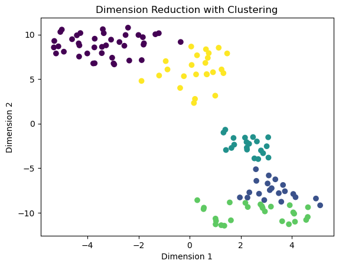

```python
# plotting
plt.scatter(reduced_data[:, 0], reduced_data[:, 1], c=cluster_labels)
plt.xlabel('Dimension 1')
plt.ylabel('Dimension 2')
plt.title('Dimension Reduction with Clustering')
plt.show()
```

### 2- Pipeline without t-SNE

```python
# pipeline definition for normalization, PCA and clustering
pipeline = Pipeline([
    ('scaler', StandardScaler()),
    ('pca', PCA(n_components=2)),
    ('kmeans', KMeans(n_clusters=5))
])
```

```python
reduced_data1 = pipeline.fit_transform(data)
cluster_labels1 = kmeans.fit_predict(reduced_data1)
```

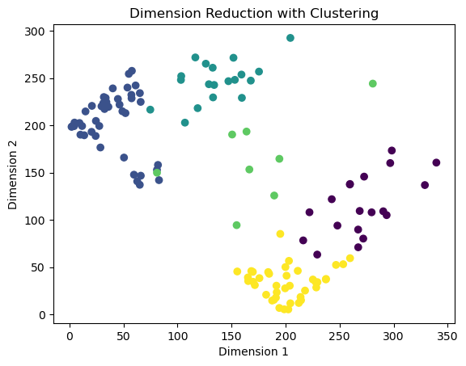

```python
# plotting
plt.scatter(reduced_data1[:, 0], reduced_data1[:, 1], c=cluster_labels1)
plt.xlabel('Dimension 1')
plt.ylabel('Dimension 2')
plt.title('Dimension Reduction with Clustering')
plt.show()
```

## Evaluation:

#### Silhouette Score:

The silhouette score measures the compactness and separation of clusters. A higher silhouette score indicates better-defined and well-separated clusters.

```python
from sklearn.metrics import silhouette_score

silhouette_score = silhouette_score(data, cluster_labels)
print("Silhouette Score (Pipeline 1):", silhouette_score)
```

```
Silhouette Score (Pipeline 1): 0.07564931366824576
```

```python
from sklearn.metrics import silhouette_score
silhouette_score1 = silhouette_score(data, cluster_labels1)
print("Silhouette Score (Pipeline 2):", silhouette_score1)
```

```
Silhouette Score (Pipeline 2): 0.10072886239361639
```

# CONCLUSION:

I first loaded the data. Then using pipeline preprocessed data.I had 2 approaches:

1- use pipeline for normalization, PCA, and t_SNE , Then clustering

2- use pipeline without t-SNE

I run both approaches, and visualize them. As the plots shows, when we use 2 dimension reduction methods(PCA and t-SNE), and then cluster the data by K-means, it gives use better results than using one dimension reduction method.

However, by evaluating the methods based on silhouette matrix, it shows that without t-SNE the accuracy is better.

# gridsearchCV

#### gridsearchCV on the second approach

```python
hyperparams = {
    "kmeans__n_clusters": [2, 3, 4, 5, 6],
    "kmeans__random_state": [42],
    "kmeans__init": ['k-means++', 'random']
}
```

```python
# pipeline definition for normalization, PCA and clustering
pipeline = Pipeline([
    ('scaler', StandardScaler()),
    ('pca', PCA(n_components=2)),
    ('kmeans', KMeans())
])
```

```python
# Instantiate the GridSearchCV object with the Pipeline object and parameter grid
grid_search = GridSearchCV(estimator=pipeline, param_grid=hyperparams, cv=10, n_jobs=-1)

# Fit the GridSearchCV object to the data
grid_search.fit(data)

# Access the best combination of hyperparameters and the corresponding evaluation metric score
print(grid_search.best_params_)
print(grid_search.best_score_)
```

```
{'kmeans__init': 'k-means++', 'kmeans__n_clusters': 6, 'kmeans__random_state': 42}
-25311.65673546427
```

## Explanation and conclusion:

GridSearchCV is a class in scikit-learn that performs an exhaustive search over a specified parameter grid to find the best combination of hyperparameters for a given estimator.

I used this class to find the best combination Kmeans parameters. The results shows that:

The best k-mean clustering is with 'kmeans**init': 'k-means++', 'kmeans**n_clusters': 6, 'kmeans__random_state': 42.

### NOTE:

I tried to find the best t-SNE with GridSearchCV, But could not run and encounter an error. So I just test it on the pipeline that contains the Kmeans.